# Project 1

# Background

```r
library(tidyverse)
tuesdata <- tidytuesdayR::tt_load('2020-01-21')
```

```
## --- Compiling #TidyTuesday Information for 2020-01-21 ----
```

```
## --- There is 1 file available ---
```

```
## --- Starting Download ---
```

```
## --- Download complete ---
```

```r
spotify_songs <- tuesdata$spotify_songs
glimpse(spotify_songs)
```

```
## Rows: 32,833
## Columns: 23
## $ track_id                 <chr> "6f807x0ima9a1j3VPbc7VN", "0r7CVbZTWZgbTCYdfa…
## $ track_name               <chr> "I Don't Care (with Justin Bieber) - Loud Lux…
## $ track_artist             <chr> "Ed Sheeran", "Maroon 5", "Zara Larsson", "Th…
## $ track_popularity         <dbl> 66, 67, 70, 60, 69, 67, 62, 69, 68, 67, 58, 6…
## $ track_album_id           <chr> "2oCs0DGTsRO98Gh5ZSl2Cx", "63rPSO264uRjW1X5E6…
## $ track_album_name         <chr> "I Don't Care (with Justin Bieber) [Loud Luxu…
## $ track_album_release_date <chr> "2019-06-14", "2019-12-13", "2019-07-05", "20…
## $ playlist_name            <chr> "Pop Remix", "Pop Remix", "Pop Remix", "Pop R…
## $ playlist_id              <chr> "37i9dQZF1DXcZDD7cfEKhW", "37i9dQZF1DXcZDD7cf…
## $ playlist_genre           <chr> "pop", "pop", "pop", "pop", "pop", "pop", "po…
## $ playlist_subgenre        <chr> "dance pop", "dance pop", "dance pop", "dance…
## $ danceability             <dbl> 0.748, 0.726, 0.675, 0.718, 0.650, 0.675, 0.4…
## $ energy                   <dbl> 0.916, 0.815, 0.931, 0.930, 0.833, 0.919, 0.8…
## $ key                      <dbl> 6, 11, 1, 7, 1, 8, 5, 4, 8, 2, 6, 8, 1, 5, 5,…
## $ loudness                 <dbl> -2.634, -4.969, -3.432, -3.778, -4.672, -5.38…
## $ mode                     <dbl> 1, 1, 0, 1, 1, 1, 0, 0, 1, 1, 1, 1, 1, 0, 0, …
## $ speechiness              <dbl> 0.0583, 0.0373, 0.0742, 0.1020, 0.0359, 0.127…
## $ acousticness             <dbl> 0.10200, 0.07240, 0.07940, 0.02870, 0.08030, …
## $ instrumentalness         <dbl> 0.00e+00, 4.21e-03, 2.33e-05, 9.43e-06, 0.00e…
## $ liveness                 <dbl> 0.0653, 0.3570, 0.1100, 0.2040, 0.0833, 0.143…
## $ valence                  <dbl> 0.518, 0.693, 0.613, 0.277, 0.725, 0.585, 0.1…
## $ tempo                    <dbl> 122.036, 99.972, 124.008, 121.956, 123.976, 1…
## $ duration_ms              <dbl> 194754, 162600, 176616, 169093, 189052, 16304…
```

# Part 1: Explore data

1. How many songs are in each genre?

```r
genre <- group_by(spotify_songs, playlist_genre) %>% count()
genre
```

```
## # A tibble: 6 × 2
## # Groups:   playlist_genre [6]
##   playlist_genre     n
##   <chr>          <int>
## 1 edm             6043
## 2 latin           5155
## 3 pop             5507
## 4 r&b             5431
## 5 rap             5746
## 6 rock            4951
```

2. What is the average level of energy and acousticness in the latin genre in this dataset?

```r
latin <- filter(spotify_songs, playlist_genre == "latin")
mean(latin$energy, na.rm = TRUE)
```

```
## [1] 0.7083125
```

```r
mean(latin$acousticness, na.rm = TRUE)
```

```
## [1] 0.2109204
```

3. Calculate the average duration of song (in minutes) across all subgenres. Which subgenre has the longest song on average?

```r
subgenre <- group_by(spotify_songs, playlist_subgenre) %>% summarize(submeans = mean(duration_ms, na.rm = TRUE)) %>% arrange(desc(submeans))
subgenre
```

```
## # A tibble: 24 × 2
##    playlist_subgenre         submeans
##    <chr>                        <dbl>
##  1 new jack swing             275129.
##  2 classic rock               256667.
##  3 album rock                 255363.
##  4 progressive electro house  254006.
##  5 southern hip hop           247029.
##  6 permanent wave             244211.
##  7 hard rock                  239897.
##  8 neo soul                   239198.
##  9 electropop                 235877.
## 10 urban contemporary         228450.
## # … with 14 more rows
```

```r
## Answer: new jack swing has the longest song on average
```

4. Make two boxplots side-by-side of the danceability of songs stratifying by whether a song has a fast or slow tempo. Define fast tempo as any song that has a tempo above its median value. On average, which songs are more danceable?

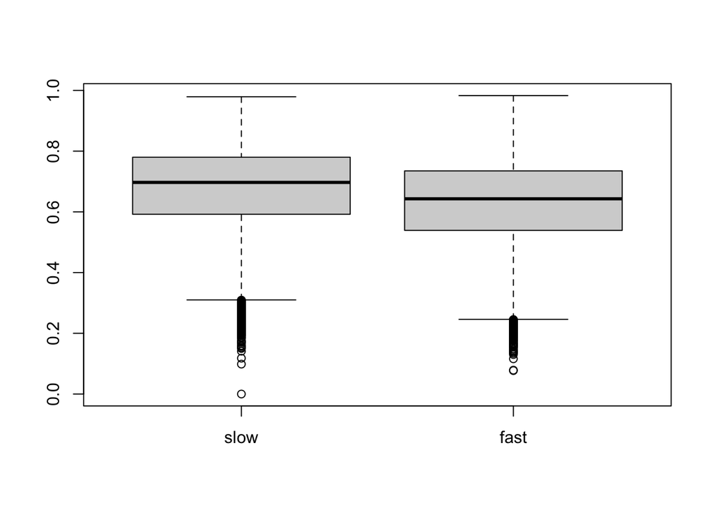

```r
slow <- filter(spotify_songs, tempo <= median(tempo, na.rm = TRUE))
fast <- filter(spotify_songs, tempo > median(tempo, na.rm = TRUE))
xlabels <- c("slow", "fast")
boxplot(slow$danceability, fast$danceability,
        names = xlabels)
```

```r
## Answer: on average, slow songs are more danceable
```

# Part 2: Convert nontidy data into tidy date

```r
library(tidyverse)

## 1. Select only unique distinct rows based on track_name and track_artist
uniq <- distinct(spotify_songs, track_name, track_artist, .keep_all = TRUE)

## 2. Add a new column called year_released listing just the year that the song was released
library(lubridate)
uniq <- mutate(uniq, year_released = format(ymd(uniq$track_album_release_date, truncated = 2), format = "%Y"))

## 3. Keep only songs released on or after 1980
uniq <- filter(uniq, uniq$year_released >= 1980)

## 4. Add new column with duration of the song in minutes
uniq <- mutate(uniq, duration_min = duration_ms/60000)

## 5. For each year released, calculate the mean of at least 6 audio features or descriptors
means_by_year <- group_by(uniq, year_released) %>%
        summarize(danceability = mean(danceability, na.rm = TRUE),
                  energy = mean(energy, na.rm = TRUE),
                  loudness = mean(loudness, na.rm = TRUE),
                  speechiness = mean(speechiness, na.rm = TRUE),
                  valence = mean(valence, na.rm = TRUE),
                  duration_min = mean(duration_min, na.rm = TRUE)) %>%
        arrange(desc(year_released))

## 6. Convert to a long dataset with feature and mean_score columns
means_by_year <- pivot_longer(means_by_year, danceability:duration_min, names_to = "feature", values_to = "mean_score")
means_by_year
```

```
## # A tibble: 246 × 3
##    year_released feature      mean_score
##    <chr>         <chr>             <dbl>
##  1 2020          danceability      0.667
##  2 2020          energy            0.673
##  3 2020          loudness         -6.88
##  4 2020          speechiness       0.115
##  5 2020          valence           0.471
##  6 2020          duration_min      3.24
##  7 2019          danceability      0.674
##  8 2019          energy            0.697
##  9 2019          loudness         -6.46
## 10 2019          speechiness       0.115
## # … with 236 more rows
```

# Part 3: Data visualization

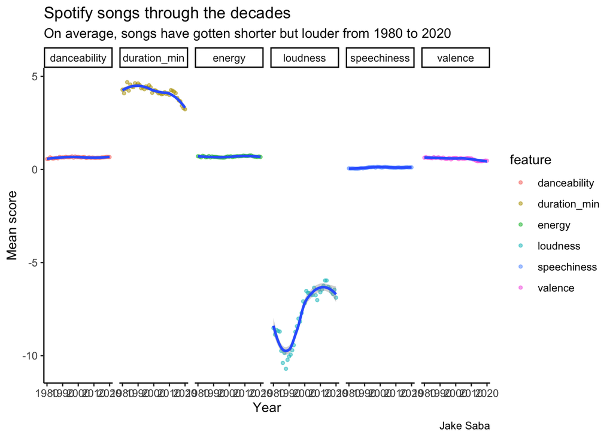

```r
## Use the functions in ggplot2 package to make a scatter plot of the six mean_scores (y-axis) over time (x-axis) with the following features
## 1. An overall title for the plot and a subtitle summarizing key trends that you found. Also include a caption in the figure with your name.
## 2. Both the observed points for the mean_score, but also a smoothed non-linear pattern of the trend
## 3. All six (or more) plots should be shown in the one figure
## 4. There should be an informative x-axis and y-axis label

g <- ggplot(means_by_year, aes(as.numeric(year_released), as.numeric(mean_score))) +
        geom_point(aes(color = feature), size = 1, alpha = 0.5) +
        labs(title = "Spotify songs through the decades", subtitle = "On average, songs have gotten shorter but louder from 1980 to 2020", x = "Year", y = "Mean score", caption = "Jake Saba") +
        facet_grid(. ~ feature, scales = "free_y", as.table = TRUE) +
        geom_smooth() +
        theme_classic()
print(g)
```

# Part 4: Make the worst plot you can!

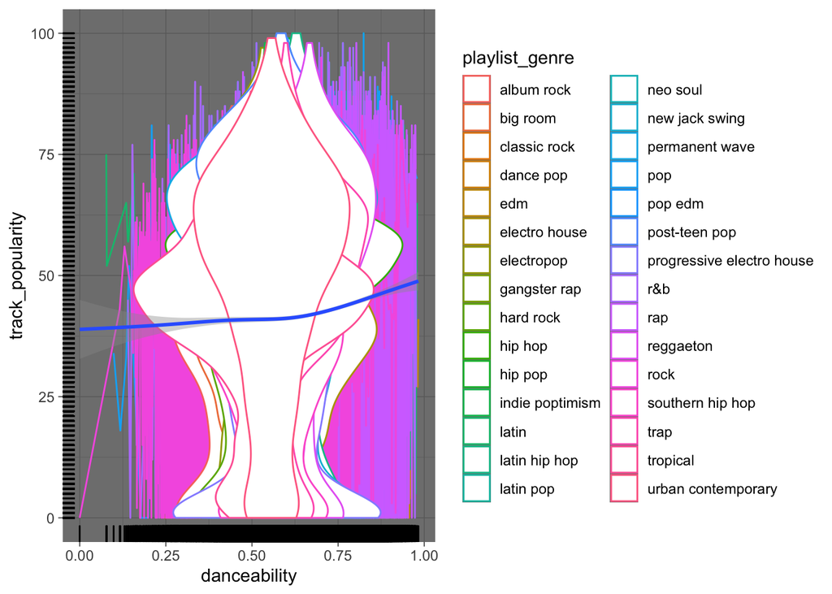

```r
ggplot(spotify_songs, aes(x = danceability, y = track_popularity)) +
        geom_rug() +
        theme_dark() +
        geom_line(aes(color = playlist_genre)) +
        geom_violin(aes(color = playlist_subgenre)) +
        stat_smooth()
```

#### Problems with plot

- Plotted as a geom_rug() plot which is difficult to interpret
- Made it theme_dark() which provides poor contrast with the bars of the geom_rug chart
- Added a geom_line() layer which made a huge squiggly line through the whole plot
- Colored geom_line() layer stratified by the playlist genre which made an ugly rainbow
- Added a geom_violin() layer which put a violin plot directly over the rest of the plot
- Colored geom_violin() layer stratified by subgenre, which made a bunch of violin plots with rainbow colors
- Added a stat_smooth() layer which placed a blue smooth line through the plot

# Part 5: Make my plot a better plot!

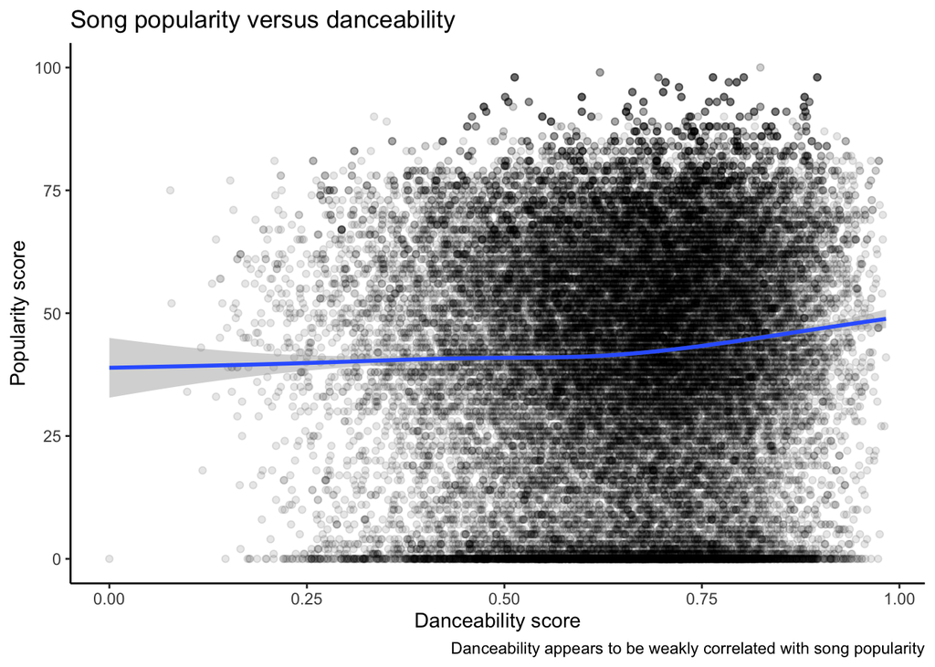

```r
ggplot(spotify_songs, aes(x = danceability, y = track_popularity)) +
        geom_point(alpha = 0.1) +
        theme_classic() +
        geom_smooth() +
        labs(title = "Song popularity versus danceability", x = "Danceability score", y = "Popularity score", caption = "Danceability appears to be weakly correlated with song popularity")
```

#### Improvements to plot

- Removed extraneous geom_line(), geom_violin(), and stat_smooth() layers along with associated color schemes
- Changed theme_dark() to theme_classic()
- Changed geom_rug() to geom_point() to generate a scatter plot
- Set the alpha within geom_point() equal to 0.1 so that dot density could be more easily visualized
- Added a geom_smooth() layer to visualize if there is any trend
- Added an informative title and caption
- Added informative X and Y labels